# Optimal Treatment Analysis

## Outcome Variable

**Outcome Variable:** ever_stunted

## Predictor Variables

**Intervention Variable:** nrooms

**Adjustment Set:**

- arm
- sex
- W_mage
- meducyrs
- feducyrs
- hhwealth_quart
- hfoodsec
- W_mhtcm
- W_nchldlt5
- W_parity
- impfloor
- impsan
- safeh20
- delta_W_mage
- delta_meducyrs
- delta_feducyrs
- delta_hhwealth_quart
- delta_hfoodsec
- delta_W_mhtcm
- delta_W_nchldlt5
- delta_W_parity
- delta_impfloor
- delta_impsan
- delta_safeh20

## Stratifying Variables

The analysis was stratified on these variable(s):

- agecat
- studyid
- country

## Data Summary

| agecat | studyid | country | nrooms | ever_stunted | n_cell | n |
| --- | --- | --- | --- | --- | --- | --- |
| 0-24 months | ki0047075b-MAL-ED | BANGLADESH | 1 | 0 | 56 | 242 |
| 0-24 months | ki0047075b-MAL-ED | BANGLADESH | 1 | 1 | 96 | 242 |
| 0-24 months | ki0047075b-MAL-ED | BANGLADESH | 2 | 0 | 19 | 242 |
| 0-24 months | ki0047075b-MAL-ED | BANGLADESH | 2 | 1 | 31 | 242 |
| 0-24 months | ki0047075b-MAL-ED | BANGLADESH | 3 | 0 | 11 | 242 |
| 0-24 months | ki0047075b-MAL-ED | BANGLADESH | 3 | 1 | 17 | 242 |
| 0-24 months | ki0047075b-MAL-ED | BANGLADESH | 4+ | 0 | 8 | 242 |
| 0-24 months | ki0047075b-MAL-ED | BANGLADESH | 4+ | 1 | 4 | 242 |
| 0-24 months | ki0047075b-MAL-ED | BRAZIL | 1 | 0 | 4 | 210 |
| 0-24 months | ki0047075b-MAL-ED | BRAZIL | 1 | 1 | 0 | 210 |
| 0-24 months | ki0047075b-MAL-ED | BRAZIL | 2 | 0 | 16 | 210 |
| 0-24 months | ki0047075b-MAL-ED | BRAZIL | 2 | 1 | 4 | 210 |
| 0-24 months | ki0047075b-MAL-ED | BRAZIL | 3 | 0 | 42 | 210 |
| 0-24 months | ki0047075b-MAL-ED | BRAZIL | 3 | 1 | 17 | 210 |
| 0-24 months | ki0047075b-MAL-ED | BRAZIL | 4+ | 0 | 99 | 210 |
| 0-24 months | ki0047075b-MAL-ED | BRAZIL | 4+ | 1 | 28 | 210 |
| 0-24 months | ki0047075b-MAL-ED | INDIA | 1 | 0 | 39 | 235 |
| 0-24 months | ki0047075b-MAL-ED | INDIA | 1 | 1 | 45 | 235 |
| 0-24 months | ki0047075b-MAL-ED | INDIA | 2 | 0 | 21 | 235 |
| 0-24 months | ki0047075b-MAL-ED | INDIA | 2 | 1 | 57 | 235 |
| 0-24 months | ki0047075b-MAL-ED | INDIA | 3 | 0 | 22 | 235 |
| 0-24 months | ki0047075b-MAL-ED | INDIA | 3 | 1 | 26 | 235 |
| 0-24 months | ki0047075b-MAL-ED | INDIA | 4+ | 0 | 9 | 235 |
| 0-24 months | ki0047075b-MAL-ED | INDIA | 4+ | 1 | 16 | 235 |
| 0-24 months | ki0047075b-MAL-ED | NEPAL | 1 | 0 | 33 | 236 |
| 0-24 months | ki0047075b-MAL-ED | NEPAL | 1 | 1 | 19 | 236 |
| 0-24 months | ki0047075b-MAL-ED | NEPAL | 2 | 0 | 22 | 236 |
| 0-24 months | ki0047075b-MAL-ED | NEPAL | 2 | 1 | 9 | 236 |
| 0-24 months | ki0047075b-MAL-ED | NEPAL | 3 | 0 | 12 | 236 |
| 0-24 months | ki0047075b-MAL-ED | NEPAL | 3 | 1 | 10 | 236 |

[output cut: 354 more lines]

The following strata were considered:

- agecat: 0-24 months, studyid: ki0047075b-MAL-ED, country: BANGLADESH
- agecat: 0-24 months, studyid: ki0047075b-MAL-ED, country: BRAZIL
- agecat: 0-24 months, studyid: ki0047075b-MAL-ED, country: INDIA
- agecat: 0-24 months, studyid: ki0047075b-MAL-ED, country: NEPAL
- agecat: 0-24 months, studyid: ki0047075b-MAL-ED, country: PERU
- agecat: 0-24 months, studyid: ki0047075b-MAL-ED, country: SOUTH AFRICA
- agecat: 0-24 months, studyid: ki0047075b-MAL-ED, country: TANZANIA, UNITED REPUBLIC OF
- agecat: 0-24 months, studyid: ki1000108-CMC-V-BCS-2002, country: INDIA
- agecat: 0-24 months, studyid: ki1000108-IRC, country: INDIA
- agecat: 0-24 months, studyid: ki1017093b-PROVIDE, country: BANGLADESH
- agecat: 0-24 months, studyid: ki1017093c-NIH-Crypto, country: BANGLADESH
- agecat: 0-24 months, studyid: ki1113344-GMS-Nepal, country: NEPAL
- agecat: 0-24 months, studyid: ki1114097-CONTENT, country: PERU
- agecat: 0-24 months, studyid: ki1135781-COHORTS, country: INDIA
- agecat: 0-24 months, studyid: kiGH5241-JiVitA-3, country: BANGLADESH
- agecat: 0-24 months, studyid: kiGH5241-JiVitA-4, country: BANGLADESH
- agecat: 0-6 months, studyid: ki0047075b-MAL-ED, country: BANGLADESH
- agecat: 0-6 months, studyid: ki0047075b-MAL-ED, country: BRAZIL
- agecat: 0-6 months, studyid: ki0047075b-MAL-ED, country: INDIA
- agecat: 0-6 months, studyid: ki0047075b-MAL-ED, country: NEPAL
- agecat: 0-6 months, studyid: ki0047075b-MAL-ED, country: PERU
- agecat: 0-6 months, studyid: ki0047075b-MAL-ED, country: SOUTH AFRICA
- agecat: 0-6 months, studyid: ki0047075b-MAL-ED, country: TANZANIA, UNITED REPUBLIC OF
- agecat: 0-6 months, studyid: ki1000108-CMC-V-BCS-2002, country: INDIA
- agecat: 0-6 months, studyid: ki1000108-IRC, country: INDIA
- agecat: 0-6 months, studyid: ki1017093b-PROVIDE, country: BANGLADESH
- agecat: 0-6 months, studyid: ki1017093c-NIH-Crypto, country: BANGLADESH
- agecat: 0-6 months, studyid: ki1113344-GMS-Nepal, country: NEPAL
- agecat: 0-6 months, studyid: ki1114097-CONTENT, country: PERU
- agecat: 0-6 months, studyid: ki1135781-COHORTS, country: INDIA
- agecat: 0-6 months, studyid: kiGH5241-JiVitA-3, country: BANGLADESH
- agecat: 0-6 months, studyid: kiGH5241-JiVitA-4, country: BANGLADESH
- agecat: 6-24 months, studyid: ki0047075b-MAL-ED, country: BANGLADESH
- agecat: 6-24 months, studyid: ki0047075b-MAL-ED, country: BRAZIL
- agecat: 6-24 months, studyid: ki0047075b-MAL-ED, country: INDIA
- agecat: 6-24 months, studyid: ki0047075b-MAL-ED, country: NEPAL
- agecat: 6-24 months, studyid: ki0047075b-MAL-ED, country: PERU
- agecat: 6-24 months, studyid: ki0047075b-MAL-ED, country: SOUTH AFRICA
- agecat: 6-24 months, studyid: ki0047075b-MAL-ED, country: TANZANIA, UNITED REPUBLIC OF
- agecat: 6-24 months, studyid: ki1000108-CMC-V-BCS-2002, country: INDIA
- agecat: 6-24 months, studyid: ki1000108-IRC, country: INDIA
- agecat: 6-24 months, studyid: ki1017093b-PROVIDE, country: BANGLADESH
- agecat: 6-24 months, studyid: ki1017093c-NIH-Crypto, country: BANGLADESH
- agecat: 6-24 months, studyid: ki1113344-GMS-Nepal, country: NEPAL
- agecat: 6-24 months, studyid: ki1114097-CONTENT, country: PERU
- agecat: 6-24 months, studyid: ki1135781-COHORTS, country: INDIA
- agecat: 6-24 months, studyid: kiGH5241-JiVitA-3, country: BANGLADESH
- agecat: 6-24 months, studyid: kiGH5241-JiVitA-4, country: BANGLADESH

### Dropped Strata

Some strata were dropped due to rare outcomes:

- agecat: 0-24 months, studyid: ki0047075b-MAL-ED, country: BANGLADESH
- agecat: 0-24 months, studyid: ki0047075b-MAL-ED, country: BRAZIL
- agecat: 0-24 months, studyid: ki0047075b-MAL-ED, country: PERU
- agecat: 0-24 months, studyid: ki1000108-CMC-V-BCS-2002, country: INDIA
- agecat: 0-24 months, studyid: ki1000108-IRC, country: INDIA
- agecat: 0-6 months, studyid: ki0047075b-MAL-ED, country: BANGLADESH
- agecat: 0-6 months, studyid: ki0047075b-MAL-ED, country: BRAZIL
- agecat: 0-6 months, studyid: ki0047075b-MAL-ED, country: NEPAL
- agecat: 0-6 months, studyid: ki1017093b-PROVIDE, country: BANGLADESH
- agecat: 6-24 months, studyid: ki0047075b-MAL-ED, country: BANGLADESH
- agecat: 6-24 months, studyid: ki0047075b-MAL-ED, country: BRAZIL
- agecat: 6-24 months, studyid: ki0047075b-MAL-ED, country: NEPAL
- agecat: 6-24 months, studyid: ki0047075b-MAL-ED, country: PERU
- agecat: 6-24 months, studyid: ki0047075b-MAL-ED, country: SOUTH AFRICA
- agecat: 6-24 months, studyid: ki0047075b-MAL-ED, country: TANZANIA, UNITED REPUBLIC OF
- agecat: 6-24 months, studyid: ki1000108-CMC-V-BCS-2002, country: INDIA
- agecat: 6-24 months, studyid: ki1000108-IRC, country: INDIA
- agecat: 6-24 months, studyid: ki1017093b-PROVIDE, country: BANGLADESH
- agecat: 6-24 months, studyid: ki1114097-CONTENT, country: PERU

## Methods Detail

We’re interested in the causal parameters $E[Y_a]$ for all values of $a \in \mathcal{A}$. These parameters represent the mean outcome if, possibly contrary to fact, we intervened to set all units to have $A=a$. Under the randomization and positivity assumptions, these are identified by the statistical parameters $\psi_a=E_W[E_{Y|A,W}(Y|A=a,W)]$. In addition, we’re interested in the mean of $Y$, $E[Y]$ under no intervention (the observed mean). We will estimate these parameters by using SuperLearner to fit the relevant likelihood factors – $E_{Y|A,W}(Y|A=a,W)$ and $p(A=a|W)$, and then updating our likelihood fit using a joint TMLE.

For unadjusted analyses ($W=\{\}$), initial likelihoods were estimated using Lrnr_glm to estimate the simple $E(Y|A)$ and Lrnr_mean to estimate $p(A)$. For adjusted analyses, a small library containing Lrnr_glmnet, Lrnr_xgboost, and Lrnr_mean was used.

Having estimated these parameters, we will then use the delta method to estimate relative risks and attributable risks relative to a prespecified baseline level of $A$.

# Results Detail

## Results Plots

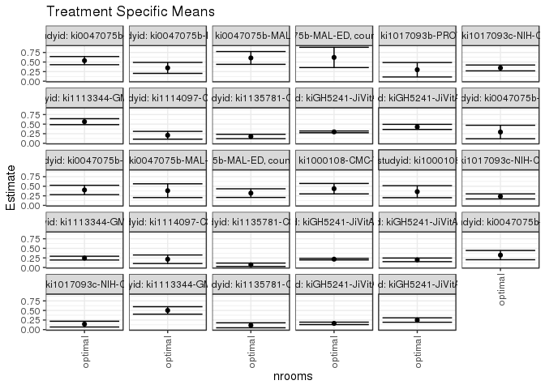

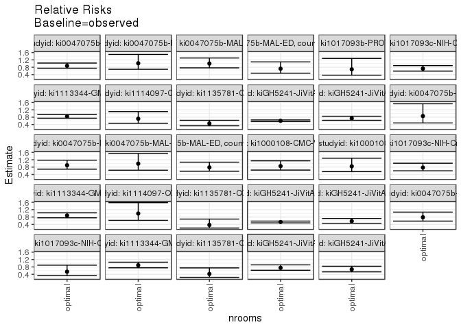

## Results Table

### Parameter: TSM

| agecat | studyid | country | intervention_level | baseline_level | estimate | ci_lower | ci_upper |
| --- | --- | --- | --- | --- | --- | --- | --- |
| 0-24 months | ki0047075b-MAL-ED | INDIA | optimal | NA | 0.5369077 | 0.4300282 | 0.6437872 |
| 0-24 months | ki0047075b-MAL-ED | NEPAL | optimal | NA | 0.3469074 | 0.2037307 | 0.4900841 |
| 0-24 months | ki0047075b-MAL-ED | SOUTH AFRICA | optimal | NA | 0.6068487 | 0.4394025 | 0.7742950 |
| 0-24 months | ki0047075b-MAL-ED | TANZANIA, UNITED REPUBLIC OF | optimal | NA | 0.6204185 | 0.3554127 | 0.8854243 |
| 0-24 months | ki1017093b-PROVIDE | BANGLADESH | optimal | NA | 0.2985913 | 0.1103961 | 0.4867866 |
| 0-24 months | ki1017093c-NIH-Crypto | BANGLADESH | optimal | NA | 0.3455898 | 0.2696086 | 0.4215709 |
| 0-24 months | ki1113344-GMS-Nepal | NEPAL | optimal | NA | 0.5642193 | 0.4866475 | 0.6417912 |
| 0-24 months | ki1114097-CONTENT | PERU | optimal | NA | 0.2090517 | 0.1073888 | 0.3107146 |
| 0-24 months | ki1135781-COHORTS | INDIA | optimal | NA | 0.1777481 | 0.1204345 | 0.2350618 |
| 0-24 months | kiGH5241-JiVitA-3 | BANGLADESH | optimal | NA | 0.2981260 | 0.2750514 | 0.3212007 |
| 0-24 months | kiGH5241-JiVitA-4 | BANGLADESH | optimal | NA | 0.4278511 | 0.3613850 | 0.4943171 |
| 0-6 months | ki0047075b-MAL-ED | INDIA | optimal | NA | 0.2937896 | 0.1173352 | 0.4702439 |
| 0-6 months | ki0047075b-MAL-ED | PERU | optimal | NA | 0.4026868 | 0.2803573 | 0.5250164 |
| 0-6 months | ki0047075b-MAL-ED | SOUTH AFRICA | optimal | NA | 0.3840280 | 0.2042116 | 0.5638444 |
| 0-6 months | ki0047075b-MAL-ED | TANZANIA, UNITED REPUBLIC OF | optimal | NA | 0.3200707 | 0.2074752 | 0.4326662 |
| 0-6 months | ki1000108-CMC-V-BCS-2002 | INDIA | optimal | NA | 0.4358832 | 0.2997671 | 0.5719993 |
| 0-6 months | ki1000108-IRC | INDIA | optimal | NA | 0.3582649 | 0.2011672 | 0.5153626 |
| 0-6 months | ki1017093c-NIH-Crypto | BANGLADESH | optimal | NA | 0.2344360 | 0.1684099 | 0.3004621 |
| 0-6 months | ki1113344-GMS-Nepal | NEPAL | optimal | NA | 0.2448206 | 0.1950696 | 0.2945716 |
| 0-6 months | ki1114097-CONTENT | PERU | optimal | NA | 0.2151462 | 0.1033020 | 0.3269904 |
| 0-6 months | ki1135781-COHORTS | INDIA | optimal | NA | 0.0705756 | 0.0266425 | 0.1145088 |
| 0-6 months | kiGH5241-JiVitA-3 | BANGLADESH | optimal | NA | 0.2172475 | 0.1971392 | 0.2373557 |
| 0-6 months | kiGH5241-JiVitA-4 | BANGLADESH | optimal | NA | 0.1999285 | 0.1530906 | 0.2467663 |
| 6-24 months | ki0047075b-MAL-ED | INDIA | optimal | NA | 0.3232933 | 0.2021130 | 0.4444736 |
| 6-24 months | ki1017093c-NIH-Crypto | BANGLADESH | optimal | NA | 0.1427220 | 0.0673624 | 0.2180816 |
| 6-24 months | ki1113344-GMS-Nepal | NEPAL | optimal | NA | 0.5001654 | 0.4027636 | 0.5975673 |
| 6-24 months | ki1135781-COHORTS | INDIA | optimal | NA | 0.1121253 | 0.0474041 | 0.1768466 |
| 6-24 months | kiGH5241-JiVitA-3 | BANGLADESH | optimal | NA | 0.1625424 | 0.1305006 | 0.1945842 |
| 6-24 months | kiGH5241-JiVitA-4 | BANGLADESH | optimal | NA | 0.2497650 | 0.1916728 | 0.3078572 |

### Parameter: E(Y)

| agecat | studyid | country | intervention_level | baseline_level | estimate | ci_lower | ci_upper |
| --- | --- | --- | --- | --- | --- | --- | --- |
| 0-24 months | ki0047075b-MAL-ED | INDIA | observed | NA | 0.6125271 | 0.5501142 | 0.6749400 |
| 0-24 months | ki0047075b-MAL-ED | NEPAL | observed | NA | 0.3415068 | 0.2808037 | 0.4022098 |
| 0-24 months | ki0047075b-MAL-ED | SOUTH AFRICA | observed | NA | 0.6070710 | 0.5472412 | 0.6669009 |
| 0-24 months | ki0047075b-MAL-ED | TANZANIA, UNITED REPUBLIC OF | observed | NA | 0.8608097 | 0.8177112 | 0.9039081 |
| 0-24 months | ki1017093b-PROVIDE | BANGLADESH | observed | NA | 0.4343244 | 0.3975796 | 0.4710692 |
| 0-24 months | ki1017093c-NIH-Crypto | BANGLADESH | observed | NA | 0.4765141 | 0.4409319 | 0.5120963 |
| 0-24 months | ki1113344-GMS-Nepal | NEPAL | observed | NA | 0.6743603 | 0.6368970 | 0.7118235 |
| 0-24 months | ki1114097-CONTENT | PERU | observed | NA | 0.2918097 | 0.2308286 | 0.3527907 |
| 0-24 months | ki1135781-COHORTS | INDIA | observed | NA | 0.3880559 | 0.3750264 | 0.4010853 |
| 0-24 months | kiGH5241-JiVitA-3 | BANGLADESH | observed | NA | 0.4945504 | 0.4867012 | 0.5023995 |
| 0-24 months | kiGH5241-JiVitA-4 | BANGLADESH | observed | NA | 0.5846328 | 0.5686437 | 0.6006219 |
| 0-6 months | ki0047075b-MAL-ED | INDIA | observed | NA | 0.3411465 | 0.2804333 | 0.4018597 |
| 0-6 months | ki0047075b-MAL-ED | PERU | observed | NA | 0.4481076 | 0.3888942 | 0.5073210 |
| 0-6 months | ki0047075b-MAL-ED | SOUTH AFRICA | observed | NA | 0.3893192 | 0.3295958 | 0.4490427 |
| 0-6 months | ki0047075b-MAL-ED | TANZANIA, UNITED REPUBLIC OF | observed | NA | 0.4083477 | 0.3473042 | 0.4693912 |
| 0-6 months | ki1000108-CMC-V-BCS-2002 | INDIA | observed | NA | 0.5110778 | 0.4599352 | 0.5622203 |
| 0-6 months | ki1000108-IRC | INDIA | observed | NA | 0.4256580 | 0.3776102 | 0.4737058 |
| 0-6 months | ki1017093c-NIH-Crypto | BANGLADESH | observed | NA | 0.3022772 | 0.2695675 | 0.3349869 |
| 0-6 months | ki1113344-GMS-Nepal | NEPAL | observed | NA | 0.2776009 | 0.2418063 | 0.3133955 |
| 0-6 months | ki1114097-CONTENT | PERU | observed | NA | 0.2173309 | 0.1615376 | 0.2731241 |
| 0-6 months | ki1135781-COHORTS | INDIA | observed | NA | 0.1909525 | 0.1802678 | 0.2016371 |
| 0-6 months | kiGH5241-JiVitA-3 | BANGLADESH | observed | NA | 0.4113932 | 0.4039424 | 0.4188440 |
| 0-6 months | kiGH5241-JiVitA-4 | BANGLADESH | observed | NA | 0.3478426 | 0.3326335 | 0.3630517 |
| 6-24 months | ki0047075b-MAL-ED | INDIA | observed | NA | 0.4121127 | 0.3343509 | 0.4898746 |
| 6-24 months | ki1017093c-NIH-Crypto | BANGLADESH | observed | NA | 0.2634863 | 0.2250951 | 0.3018776 |
| 6-24 months | ki1113344-GMS-Nepal | NEPAL | observed | NA | 0.5610500 | 0.5138694 | 0.6082306 |
| 6-24 months | ki1135781-COHORTS | INDIA | observed | NA | 0.2666740 | 0.2531513 | 0.2801967 |
| 6-24 months | kiGH5241-JiVitA-3 | BANGLADESH | observed | NA | 0.2166596 | 0.2073030 | 0.2260161 |
| 6-24 months | kiGH5241-JiVitA-4 | BANGLADESH | observed | NA | 0.3740206 | 0.3553187 | 0.3927225 |

### Parameter: RR

| agecat | studyid | country | intervention_level | baseline_level | estimate | ci_lower | ci_upper |
| --- | --- | --- | --- | --- | --- | --- | --- |
| 0-24 months | ki0047075b-MAL-ED | INDIA | optimal | observed | 0.8765452 | 0.7479546 | 1.0272434 |
| 0-24 months | ki0047075b-MAL-ED | NEPAL | optimal | observed | 1.0158141 | 0.6901836 | 1.4950781 |
| 0-24 months | ki0047075b-MAL-ED | SOUTH AFRICA | optimal | observed | 0.9996338 | 0.7673322 | 1.3022623 |
| 0-24 months | ki0047075b-MAL-ED | TANZANIA, UNITED REPUBLIC OF | optimal | observed | 0.7207383 | 0.4765157 | 1.0901293 |
| 0-24 months | ki1017093b-PROVIDE | BANGLADESH | optimal | observed | 0.6874846 | 0.3691958 | 1.2801743 |
| 0-24 months | ki1017093c-NIH-Crypto | BANGLADESH | optimal | observed | 0.7252456 | 0.5915442 | 0.8891664 |
| 0-24 months | ki1113344-GMS-Nepal | NEPAL | optimal | observed | 0.8366735 | 0.7431994 | 0.9419040 |
| 0-24 months | ki1114097-CONTENT | PERU | optimal | observed | 0.7163975 | 0.4652361 | 1.1031503 |
| 0-24 months | ki1135781-COHORTS | INDIA | optimal | observed | 0.4580478 | 0.3323511 | 0.6312837 |
| 0-24 months | kiGH5241-JiVitA-3 | BANGLADESH | optimal | observed | 0.6028224 | 0.5585396 | 0.6506161 |
| 0-24 months | kiGH5241-JiVitA-4 | BANGLADESH | optimal | observed | 0.7318287 | 0.6297848 | 0.8504068 |
| 0-6 months | ki0047075b-MAL-ED | INDIA | optimal | observed | 0.8611830 | 0.4865111 | 1.5243975 |
| 0-6 months | ki0047075b-MAL-ED | PERU | optimal | observed | 0.8986387 | 0.6872232 | 1.1750935 |
| 0-6 months | ki0047075b-MAL-ED | SOUTH AFRICA | optimal | observed | 0.9864090 | 0.6324598 | 1.5384421 |
| 0-6 months | ki0047075b-MAL-ED | TANZANIA, UNITED REPUBLIC OF | optimal | observed | 0.7838190 | 0.5760596 | 1.0665080 |
| 0-6 months | ki1000108-CMC-V-BCS-2002 | INDIA | optimal | observed | 0.8528706 | 0.6377918 | 1.1404790 |
| 0-6 months | ki1000108-IRC | INDIA | optimal | observed | 0.8416731 | 0.5529628 | 1.2811237 |
| 0-6 months | ki1017093c-NIH-Crypto | BANGLADESH | optimal | observed | 0.7755663 | 0.5956533 | 1.0098208 |
| 0-6 months | ki1113344-GMS-Nepal | NEPAL | optimal | observed | 0.8819158 | 0.7572129 | 1.0271555 |
| 0-6 months | ki1114097-CONTENT | PERU | optimal | observed | 0.9899478 | 0.6208051 | 1.5785897 |
| 0-6 months | ki1135781-COHORTS | INDIA | optimal | observed | 0.3695979 | 0.1988345 | 0.6870168 |
| 0-6 months | kiGH5241-JiVitA-3 | BANGLADESH | optimal | observed | 0.5280774 | 0.4822714 | 0.5782341 |
| 0-6 months | kiGH5241-JiVitA-4 | BANGLADESH | optimal | observed | 0.5747670 | 0.4573211 | 0.7223746 |
| 6-24 months | ki0047075b-MAL-ED | INDIA | optimal | observed | 0.7844779 | 0.5775636 | 1.0655199 |
| 6-24 months | ki1017093c-NIH-Crypto | BANGLADESH | optimal | observed | 0.5416675 | 0.3278849 | 0.8948376 |
| 6-24 months | ki1113344-GMS-Nepal | NEPAL | optimal | observed | 0.8914810 | 0.7521032 | 1.0566880 |
| 6-24 months | ki1135781-COHORTS | INDIA | optimal | observed | 0.4204585 | 0.2367601 | 0.7466856 |
| 6-24 months | kiGH5241-JiVitA-3 | BANGLADESH | optimal | observed | 0.7502204 | 0.6178302 | 0.9109795 |
| 6-24 months | kiGH5241-JiVitA-4 | BANGLADESH | optimal | observed | 0.6677840 | 0.5328977 | 0.8368126 |